# NHANES data summary for IndxArea SES analysis

2026-08-10

### Check variable harmonization across NHANES cycles

First, check how many participants (Age >18 years) are available at each exam cycle with BOTH the interview & MEC components

(**Participants with interview only will NOT have laboratory or exam data**)

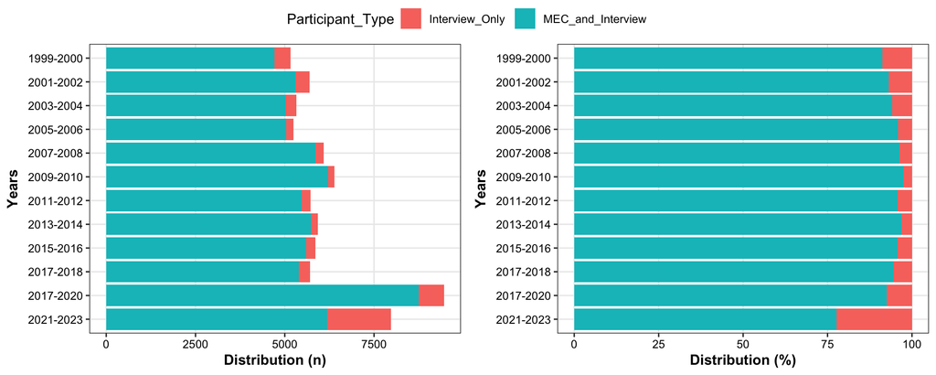

```r
nhanes_participant_types <- nhanes_processed %>%
  group_by(Years) %>%
  reframe(n=n(),
          n_type=table(RIDSTATR)) %>%
  mutate(pct=(n_type/n)*100,
         Participant_Type = rep(c("MEC_and_Interview", "Interview_Only"), 12)) %>%
  mutate_at("Years", ~factor(., levels=c(rev(unique(nhanes_processed$Years)))))

ggarrange(plotlist=list(
  nhanes_participant_types %>%
    ggplot(aes(y=Years, group=Participant_Type, x=n_type, fill=Participant_Type)) +
    geom_bar(stat="identity") + xlab("Distribution (n)") +
    ggplot_theme,
  nhanes_participant_types %>%
    ggplot(aes(y=Years, group=Participant_Type, x=pct, fill=Participant_Type)) +
    geom_bar(stat="identity") + xlab("Distribution (%)") +
    ggplot_theme
  ), nrow=1, align="hv", common.legend=T)
```

Next, summarise missingness of variables from each data category (DEMO, LAB, EXAM, QUESTIONNAIRE, DIET) among participants who completed BOTH the Interview and MEC exam

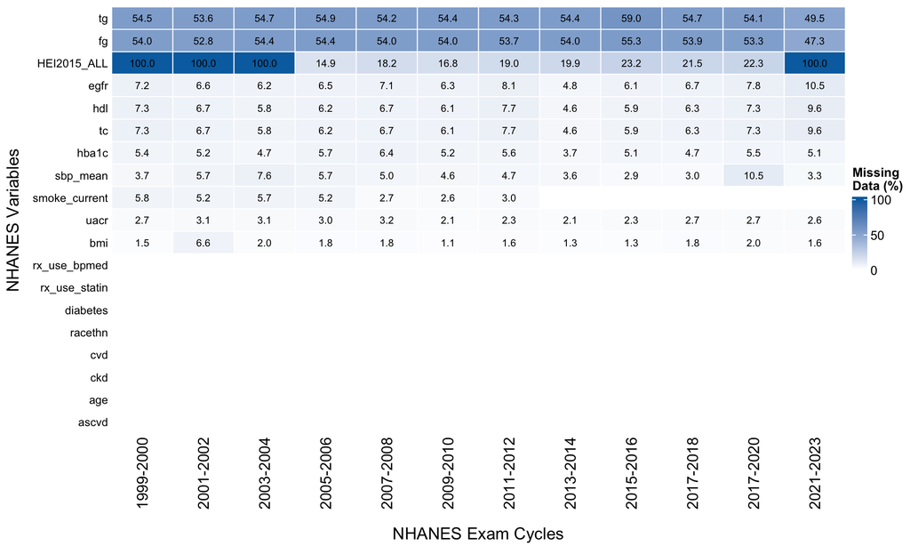

```r
# select list of variables representing all categories to check missingness
vars_checkmiss <- c("age", "racethn", "smoke_current", "bmi", "sbp_mean", "tc",
                    "hdl", "uacr", "hba1c", "fg","tg", "egfr", "cvd",
                    "ascvd", "ckd", "diabetes", "rx_use_statin", "rx_use_bpmed",
                    "HEI2015_ALL")

# summarise missingness -- before and after accounting for participant type
na_summary <- nhanes_processed %>%
  select(SEQN, Years, RIDSTATR, vars_checkmiss) %>%
  mutate(SEQN_TYPE = ifelse(RIDSTATR == "Both interviewed and MEC examined", 2, 1)) %>%
  pivot_longer(
    cols = vars_checkmiss, names_to = "variable", values_to = "value",
    values_transform = list(value = as.character)) %>%
  group_by(Years, variable) %>%
  summarize(
    n_all = n(), n_na =  sum(is.na(value)),
    pct_na = round(mean(is.na(value))*100,1),
    n_both = sum(ifelse(SEQN_TYPE == 2,1,0)),
    n_na_both = sum(ifelse(is.na(value) & SEQN_TYPE == 2,1,0)),
    pct_na_both = round((n_na_both/n_both)*100,1),
    .groups    = "drop")

# matrix of missingness, restricting to participants with BOTH data types (for analysis)
na_summary.hm <- na_summary %>%
    select(Years, variable, pct_na_both) %>%
    pivot_wider(names_from=Years, values_from=pct_na_both) %>%
    column_to_rownames("variable") %>%
    as.matrix()

# View Heatmap -----------------
Heatmap(
  na_summary.hm, cluster_columns = F, rect_gp = gpar(col = "white", lwd = 1),
  show_row_dend = F, row_names_side = "left", column_title_side = "bottom",
  column_title = "NHANES Exam Cycles", row_title = "NHANES Variables",
  name = "Missing\nData (%)", row_names_gp = gpar(fontsize=9),
  col=colorRamp2(c(0, 100), c("#FFFFFF", palettes$NatExt$Blues[3])),
  # Function to print missing value if >10%
  cell_fun = function(j, i, x, y, width, height, fill) {
    pct_na <- as.numeric(na_summary.hm[i, j])
    if (!is.na(pct_na) & pct_na>1) {
      grid.text(sprintf("%.1f", pct_na), x, y, gp = gpar(fontsize = 8, col = "black"))
      }
    })
```

*Note:* Values are provided in the boxes when % missing > 1. Missingness would seem much higher if we did not account for participants that only completed the interviews:

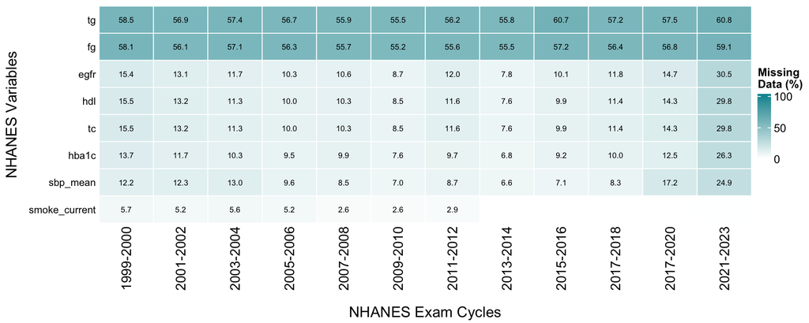